# Project Celeb Face Attributes

Kamerman

11/11/2019

# Introduction to data

One step in Data Analysis is to summarize and describe the raw information. This case, we are going the gain insight in a face recognition data base. In the data set it has overall 202,599 number of face images of various celebrities. On top of that has a raw amount of 10,177 unique identities, but names aren’t specified. Per each image there are 40 binary attributes and 5 landmark locations. The output is to try to find out who are the most attractive people are based on location, attributes,and size. The celeba-dataset website (https://www.kaggle.com/jessicali9530/celeba-dataset) has a couple of data files plus more details on the aspects of the study.

[figure not shown]

Famous People

# Questions

What is the ratio of attractive people base on there attributes?

Based on their size find the ratio of attractive famus people?

How many attractive people are there based on their partition?

Based on the varible landmark what is the ratio of attractive people?

# Packages

```r
library(ggplot2)
library(corrplot)
library(readr)
library(car)
```

# Reading the Data

```r
attr<- read.csv("list_attr_celeba.csv")
bbox<- read.csv("list_bbox_celeba.csv")
eval<- read.csv("list_eval_partition.csv")
landmarks<- read.csv("list_landmarks_align_celeba.csv")
```

# Data exploration

## Data for the attr file

```r
object.size(attr)
```

```
## 47819800 bytes
```

```r
nrow(attr)
```

```
## [1] 202599
```

```r
ncol(attr)
```

```
## [1] 41
```

```r
class(attr)
```

```
## [1] "data.frame"
```

The first file of the data set is the attr file. What is the way you organize your data show you can see the exact amount of attributes each of the people in the photos have?

```r
attr_all<-attr
attr_all[attr_all==-1]<-0
attr_all<- attr_all[sample(nrow(attr_all)),]
summary(attr_all)
```

```
##        image_id      X5_o_Clock_Shadow Arched_Eyebrows   Attractive
##  000001.jpg:     1   Min.   :0.0000    Min.   :0.000   Min.   :0.0000
##  000002.jpg:     1   1st Qu.:0.0000    1st Qu.:0.000   1st Qu.:0.0000
##  000003.jpg:     1   Median :0.0000    Median :0.000   Median :1.0000
##  000004.jpg:     1   Mean   :0.1111    Mean   :0.267   Mean   :0.5125
##  000005.jpg:     1   3rd Qu.:0.0000    3rd Qu.:1.000   3rd Qu.:1.0000
##  000006.jpg:     1   Max.   :1.0000    Max.   :1.000   Max.   :1.0000
##  (Other)   :202593
##  Bags_Under_Eyes       Bald             Bangs           Big_Lips
##  Min.   :0.0000   Min.   :0.00000   Min.   :0.0000   Min.   :0.0000
##  1st Qu.:0.0000   1st Qu.:0.00000   1st Qu.:0.0000   1st Qu.:0.0000
##  Median :0.0000   Median :0.00000   Median :0.0000   Median :0.0000
##  Mean   :0.2046   Mean   :0.02244   Mean   :0.1516   Mean   :0.2408
##  3rd Qu.:0.0000   3rd Qu.:0.00000   3rd Qu.:0.0000   3rd Qu.:0.0000
##  Max.   :1.0000   Max.   :1.00000   Max.   :1.0000   Max.   :1.0000
##
##     Big_Nose        Black_Hair       Blond_Hair        Blurry
##  Min.   :0.0000   Min.   :0.0000   Min.   :0.000   Min.   :0.0000
##  1st Qu.:0.0000   1st Qu.:0.0000   1st Qu.:0.000   1st Qu.:0.0000
##  Median :0.0000   Median :0.0000   Median :0.000   Median :0.0000
##  Mean   :0.2345   Mean   :0.2393   Mean   :0.148   Mean   :0.0509
##  3rd Qu.:0.0000   3rd Qu.:0.0000   3rd Qu.:0.000   3rd Qu.:0.0000
##  Max.   :1.0000   Max.   :1.0000   Max.   :1.000   Max.   :1.0000
##
##    Brown_Hair     Bushy_Eyebrows       Chubby         Double_Chin
##  Min.   :0.0000   Min.   :0.0000   Min.   :0.00000   Min.   :0.00000
##  1st Qu.:0.0000   1st Qu.:0.0000   1st Qu.:0.00000   1st Qu.:0.00000
##  Median :0.0000   Median :0.0000   Median :0.00000   Median :0.00000
##  Mean   :0.2052   Mean   :0.1422   Mean   :0.05757   Mean   :0.04669
##  3rd Qu.:0.0000   3rd Qu.:0.0000   3rd Qu.:0.00000   3rd Qu.:0.00000
##  Max.   :1.0000   Max.   :1.0000   Max.   :1.00000   Max.   :1.00000
##
##    Eyeglasses          Goatee          Gray_Hair        Heavy_Makeup
##  Min.   :0.00000   Min.   :0.00000   Min.   :0.00000   Min.   :0.0000
##  1st Qu.:0.00000   1st Qu.:0.00000   1st Qu.:0.00000   1st Qu.:0.0000
##  Median :0.00000   Median :0.00000   Median :0.00000   Median :0.0000
##  Mean   :0.06512   Mean   :0.06276   Mean   :0.04195   Mean   :0.3869
##  3rd Qu.:0.00000   3rd Qu.:0.00000   3rd Qu.:0.00000   3rd Qu.:1.0000
##  Max.   :1.00000   Max.   :1.00000   Max.   :1.00000   Max.   :1.0000
##
```

[output cut: 33 more lines]

```
##  Min.   :0.00000   Min.   :0.0000   Min.   :0.000    Min.   :0.00000
##  1st Qu.:0.00000   1st Qu.:0.0000   1st Qu.:0.000    1st Qu.:0.00000
##  Median :0.00000   Median :0.0000   Median :0.000    Median :0.00000
##  Mean   :0.04846   Mean   :0.4724   Mean   :0.123    Mean   :0.07272
##  3rd Qu.:0.00000   3rd Qu.:1.0000   3rd Qu.:0.000    3rd Qu.:0.00000
##  Max.   :1.00000   Max.   :1.0000   Max.   :1.000    Max.   :1.00000
##
##      Young
##  Min.   :0.0000
##  1st Qu.:1.0000
##  Median :1.0000
##  Mean   :0.7736
##  3rd Qu.:1.0000
##  Max.   :1.0000
##
```

```r
attr_train<- attr_all[1:1000,]
attr_train[1:5,]
```

```
##          image_id X5_o_Clock_Shadow Arched_Eyebrows Attractive
## 96671  096671.jpg                 0               0          1
## 83662  083662.jpg                 0               0          0
## 23881  023881.jpg                 0               0          1
## 199218 199218.jpg                 0               1          0
## 38318  038318.jpg                 1               0          1
##        Bags_Under_Eyes Bald Bangs Big_Lips Big_Nose Black_Hair Blond_Hair
## 96671                0    0     0        0        1          0          0
## 83662                0    0     0        1        0          0          1
## 23881                0    0     0        0        0          0          1
## 199218               0    0     0        0        0          0          0
## 38318                0    0     0        0        1          1          0
##        Blurry Brown_Hair Bushy_Eyebrows Chubby Double_Chin Eyeglasses
## 96671       0          0              0      0           0          0
## 83662       0          0              0      0           0          0
```

[output cut: 33 more lines]

```r
attr_test<- attr_all[10001: nrow(attr_all),]
attr_test[1:5,]
```

```
##          image_id X5_o_Clock_Shadow Arched_Eyebrows Attractive
## 49737  049737.jpg                 0               1          1
## 53432  053432.jpg                 0               0          0
## 126895 126895.jpg                 0               0          0
## 133271 133271.jpg                 0               0          0
## 33459  033459.jpg                 0               0          0
##        Bags_Under_Eyes Bald Bangs Big_Lips Big_Nose Black_Hair Blond_Hair
## 49737                0    0     0        1        0          0          1
## 53432                0    0     0        0        0          0          0
## 126895               0    0     1        1        1          1          0
## 133271               0    0     0        0        0          0          1
## 33459                0    0     1        1        1          0          0
##        Blurry Brown_Hair Bushy_Eyebrows Chubby Double_Chin Eyeglasses
## 49737       0          0              0      0           0          0
## 53432       0          1              0      0           0          0
```

[output cut: 33 more lines]

```r
attr_test_small<- attr_test[sample(nrow(attr_test),5),]
attr_test_small
```

```
##          image_id X5_o_Clock_Shadow Arched_Eyebrows Attractive
## 2894   002894.jpg                 0               0          1
## 113046 113046.jpg                 1               0          0
## 136919 136919.jpg                 0               1          1
## 22688  022688.jpg                 0               1          0
## 174294 174294.jpg                 0               1          1
##        Bags_Under_Eyes Bald Bangs Big_Lips Big_Nose Black_Hair Blond_Hair
## 2894                 0    0     0        0        0          0          0
## 113046               0    0     0        0        0          0          0
## 136919               1    0     1        1        0          0          0
## 22688                0    0     0        0        0          0          0
## 174294               0    0     0        1        0          0          0
##        Blurry Brown_Hair Bushy_Eyebrows Chubby Double_Chin Eyeglasses
## 2894        0          1              0      0           0          0
## 113046      0          0              0      0           1          0
```

[output cut: 33 more lines]

## Visualizations of Attributes

Based on the two varibles in the data set called attr_train. How do you make a pie chart with the two varibles Male and Attractive?

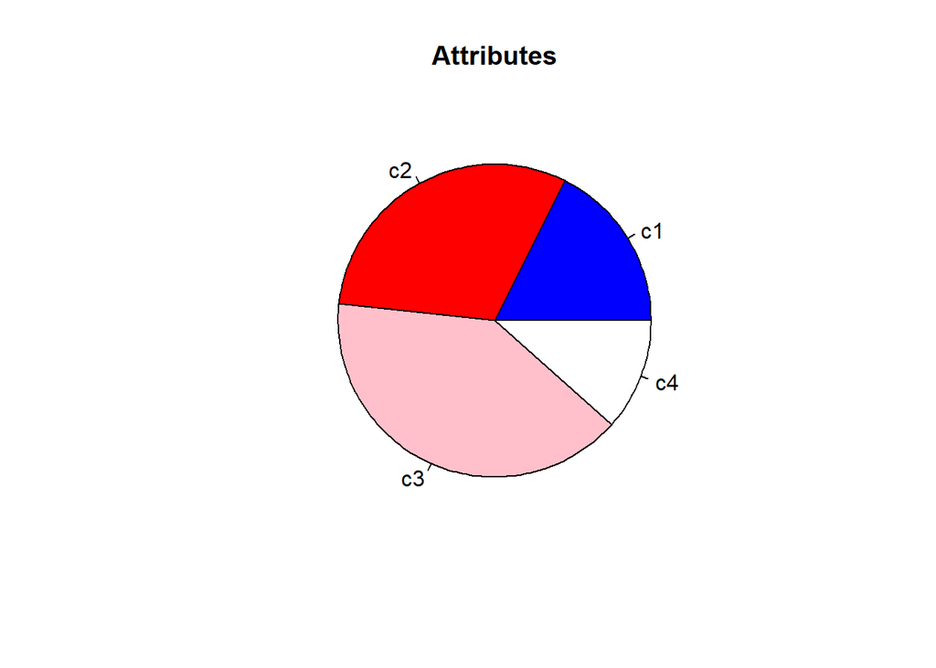

```r
pie(table(attr_train$Male,attr_train$Attractive),labels =c("c1","c2","c3","c4"),col = c("blue","red","pink","white"), main = "Attributes")
```

How do you organize the data into three varibles?

```r
f1<- Attractive~.
f2<- Attractive~ Bangs+Big_Nose+Blurry+Bushy_Eyebrows+Eyeglasses+Heavy_Makeup+Pointy_Nose+Receding_Hairline+Smiling+Wearing_Earrings+Wearing_Hat+Wearing_Lipstick+Young
f3<- Attractive~ Big_Nose+Blurry+Eyeglasses+Heavy_Makeup+Pointy_Nose+Receding_Hairline+Smiling+Wearing_Hat+Young
```

What is the methode of puting the three varibles into another varible?

```r
formulas<- list("f1", "f2", "f3")
formulas
```

```
## [[1]]
## [1] "f1"
##
## [[2]]
## [1] "f2"
##
## [[3]]
## [1] "f3"
```

```r
for (n in formulas) {
  logit1<-glm(f1,data = attr_train[2:41], family = "binomial")
summary(logit1)
p1<-predict.glm(logit1,attr_test_small[2:41], type="response")



p1<-as.data.frame(p1)
check<-cbind(as.data.frame(p1),attr_test_small$Attractive)
check$pred<-round(check$p1)
check$correct<-check$`attr_test_small$Attractive`+check$pred
check$correct<-as.factor(check$correct)
s1<-summary(check$correct)
print("The percentage of correct predictions:")
print (((s1[2]+s1[1]))/nrow(check)*100)
}
```

```
## [1] "The percentage of correct predictions:"
##  1
## 40
## [1] "The percentage of correct predictions:"
##  1
## 40
## [1] "The percentage of correct predictions:"
##  1
## 40
```

## Data for the bbox file

```r
object.size(bbox)
```

```
## 18640744 bytes
```

```r
nrow(bbox)
```

```
## [1] 202599
```

```r
ncol(bbox)
```

```
## [1] 5
```

```r
class(bbox)
```

```
## [1] "data.frame"
```

The second file of data is the bbox data. What is the way you organize your data so you change the order?

```r
bbox_all<- bbox
bbox_all<- bbox_all[sample(nrow(bbox_all)),]
summary(bbox_all)
```

```
##        image_id           x_1              y_1              width
##  000001.jpg:     1   Min.   :   1.0   Min.   :   0.00   Min.   :   0.0
##  000002.jpg:     1   1st Qu.:  69.0   1st Qu.:  44.00   1st Qu.: 120.0
##  000003.jpg:     1   Median : 110.0   Median :  68.00   Median : 164.0
##  000004.jpg:     1   Mean   : 156.8   Mean   :  84.34   Mean   : 194.8
##  000005.jpg:     1   3rd Qu.: 181.0   3rd Qu.:  98.00   3rd Qu.: 221.0
##  000006.jpg:     1   Max.   :3840.0   Max.   :1858.00   Max.   :3827.0
##  (Other)   :202593
##      height
##  Min.   :   0.0
##  1st Qu.: 166.0
##  Median : 227.0
##  Mean   : 268.9
##  3rd Qu.: 306.0
##  Max.   :5299.0
##
```

How do you select a certain number people in the bbox data file?

```r
bbox_train<- bbox_all[1:1000,]
bbox_train[1:5,]
```

```
##          image_id x_1 y_1 width height
## 151574 151574.jpg  70  39    86    119
## 1371   001371.jpg  25  31   190    263
## 97188  097188.jpg 164  95   114    158
## 81753  081753.jpg 195 289   294    407
## 36199  036199.jpg 103  86   208    288
```

```r
bbox_test<- bbox_all[10001: nrow(bbox_all),]
bbox_test[1:5,]
```

```
##          image_id x_1 y_1 width height
## 35392  035392.jpg 118  75   177    245
## 96450  096450.jpg 178  52   164    227
## 175853 175853.jpg 170  66   222    426
## 15071  015071.jpg  36  15    52     72
## 157127 157127.jpg 137  58   164    227
```

```r
bbox_test_small<- bbox_test[sample(nrow(bbox_test),5),]
bbox_test_small
```

```
##          image_id x_1 y_1 width height
## 86451  086451.jpg  92  69   101    140
## 167970 167970.jpg 158  53   122    169
## 19427  019427.jpg 132 105   153    212
## 138257 138257.jpg  68 126   226    313
## 115924 115924.jpg 180  39   226    313
```

## Visualizations based on Height

Based on the data in bbox_train, How do you make a bar graph based on the varible height?

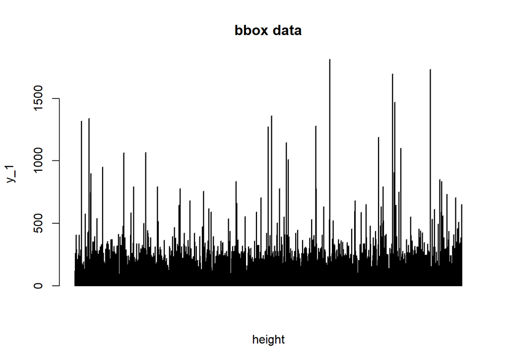

```r
barplot(bbox_train$height, main = "bbox data", xlab = "height", ylab="y_1")
```

What is the way to organize the varibles in the bbox data file?

```r
v1<- height~.
v2<-height~x_1+y_1+width
```

The most important part is, how do you set the two varibles you made into the varible formulas?

```r
formulas<- list("v1", "v2")
formulas
```

```
## [[1]]
## [1] "v1"
##
## [[2]]
## [1] "v2"
```

```r
for (n in formulas) {
  logit1<-glm(v1,data = bbox_train[2:5])
summary(logit1)
p1<-predict.glm(logit1,bbox_test_small[2:5], type="response")



p1<-as.data.frame(p1)
check<-cbind(as.data.frame(p1),bbox_test_small$height)
check$pred<-round(check$p1)
check$correct<-check$`bbox_test_small$height`+check$pred
check$correct<-as.factor(check$correct)
c1<-summary(check$correct)
print("The percentage of correct predictions:")
print (((s1[2]+s1[1]))/nrow(check)*100)
}
```

```
## [1] "The percentage of correct predictions:"
##  1
## 40
## [1] "The percentage of correct predictions:"
##  1
## 40
```

## Data for the eval file

```r
object.size(eval)
```

```
## 16209176 bytes
```

```r
nrow(eval)
```

```
## [1] 202599
```

```r
ncol(eval)
```

```
## [1] 2
```

```r
class(eval)
```

```
## [1] "data.frame"
```

This is the third file of data called eval data. What is the way to shuffle and oranize the data?

```r
eval_all<-eval
eval_all<- eval_all[sample(nrow(eval_all)),]
summary(eval_all)
```

```
##        image_id        partition
##  000001.jpg:     1   Min.   :0.0000
##  000002.jpg:     1   1st Qu.:0.0000
##  000003.jpg:     1   Median :0.0000
##  000004.jpg:     1   Mean   :0.2951
##  000005.jpg:     1   3rd Qu.:0.0000
##  000006.jpg:     1   Max.   :2.0000
##  (Other)   :202593
```

how do you control the amount of variables and observations in the data eval_train?

```r
eval_train<- eval_all[1:1000,]
eval_train[1:5,]
```

```
##          image_id partition
## 63270  063270.jpg         0
## 91592  091592.jpg         0
## 160578 160578.jpg         0
## 165920 165920.jpg         1
## 76553  076553.jpg         0
```

What is another way of narrowing down the data?

```r
eval_test<- eval_all[10001: nrow(eval_all),]
eval_test[1:5,]
```

```
##          image_id partition
## 128309 128309.jpg         0
## 103844 103844.jpg         0
## 167468 167468.jpg         1
## 133507 133507.jpg         0
## 171223 171223.jpg         1
```

```r
eval_test_small<- eval_test[sample(nrow(eval_test),5),]
eval_test_small
```

```
##          image_id partition
## 3354   003354.jpg         0
## 155249 155249.jpg         0
## 103162 103162.jpg         0
## 84961  084961.jpg         0
## 102889 102889.jpg         0
```

## Visualizations of based on partition

What is way to make a histogram from the eval_train data pertaining to the partition varible?

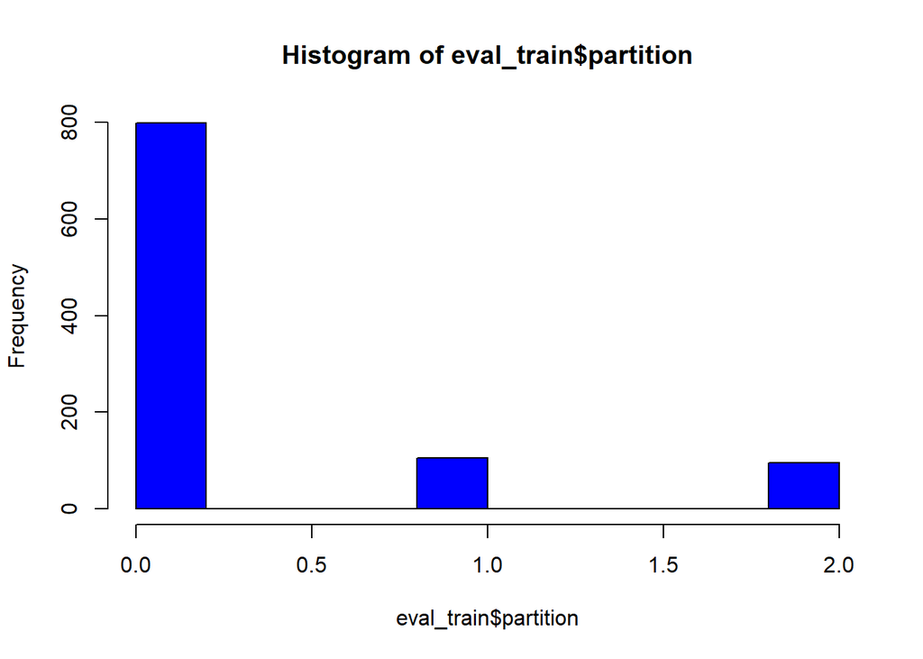

```r
hist(eval_train$partition, col = "blue")
```

What is the way to store data into a varible?

```r
f1<- partition~.
```

How do you the varible you made into the varible called formulas?

```r
formulas<- list("f1")
formulas
```

```
## [[1]]
## [1] "f1"
```

```r
for (n in formulas) {
  logit1<-glm(f1,data = eval_train[1:2])
  summary(logit1)
p1<-predict.glm(logit1,eval_train[1:2], type="response")



p1<-as.data.frame(p1)
check<-cbind(as.data.frame(p1),eval_test_small$partition)
check$pred<-round(check$p1)
check$correct<-check$`eval_test_small$partition`+check$pred
check$correct<-as.factor(check$correct)
c1<-summary(check$correct)
print("The percentage of correct predictions:")
print (((c1[2]+c1[1]))/nrow(check)*100)
}
```

```
## [1] "The percentage of correct predictions:"
##    1
## 90.4
```

## Data for the Landmark file

```r
object.size(landmarks)
```

```
## 23503992 bytes
```

```r
nrow(landmarks)
```

```
## [1] 202599
```

```r
ncol(landmarks)
```

```
## [1] 11
```

```r
class(landmarks)
```

```
## [1] "data.frame"
```

```r
landmarks_all<-landmarks
landmarks_all<- landmarks_all[sample(nrow(landmarks_all)),]
summary(landmarks_all)
```

```
##        image_id        lefteye_x       lefteye_y       righteye_x
##  000001.jpg:     1   Min.   :56.00   Min.   : 98.0   Min.   : 90.0
##  000002.jpg:     1   1st Qu.:68.00   1st Qu.:111.0   1st Qu.:107.0
##  000003.jpg:     1   Median :69.00   Median :111.0   Median :108.0
##  000004.jpg:     1   Mean   :69.35   Mean   :111.2   Mean   :107.6
##  000005.jpg:     1   3rd Qu.:70.00   3rd Qu.:112.0   3rd Qu.:109.0
##  000006.jpg:     1   Max.   :88.00   Max.   :129.0   Max.   :124.0
##  (Other)   :202593
##    righteye_y        nose_x           nose_y       leftmouth_x
##  Min.   : 95.0   Min.   : 57.00   Min.   : 93.0   Min.   :57.00
##  1st Qu.:111.0   1st Qu.: 84.00   1st Qu.:133.0   1st Qu.:69.00
##  Median :111.0   Median : 88.00   Median :135.0   Median :72.00
##  Mean   :111.2   Mean   : 88.06   Mean   :135.1   Mean   :71.25
##  3rd Qu.:112.0   3rd Qu.: 92.00   3rd Qu.:138.0   3rd Qu.:73.00
##  Max.   :122.0   Max.   :121.00   Max.   :156.0   Max.   :90.00
##
##   leftmouth_y     rightmouth_x    rightmouth_y
##  Min.   :116.0   Min.   : 82.0   Min.   :114.0
##  1st Qu.:151.0   1st Qu.:103.0   1st Qu.:151.0
##  Median :152.0   Median :105.0   Median :152.0
##  Mean   :152.1   Mean   :105.6   Mean   :152.2
##  3rd Qu.:153.0   3rd Qu.:108.0   3rd Qu.:153.0
##  Max.   :174.0   Max.   :120.0   Max.   :173.0
##
```

How do you control the bonds so you would only see a certain set of people?

```r
landmarks_train<- landmarks_all[1:1000,]
landmarks_train[1:5,]
```

```
##          image_id lefteye_x lefteye_y righteye_x righteye_y nose_x nose_y
## 110201 110201.jpg        67       112        110        113     83    143
## 23726  023726.jpg        69       111        107        111     81    139
## 100293 100293.jpg        70       111        107        111     84    131
## 161581 161581.jpg        71       111        107        110     88    128
## 149956 149956.jpg        69       111        108        111     94    136
##        leftmouth_x leftmouth_y rightmouth_x rightmouth_y
## 110201          66         149          112          151
## 23726           75         152          102          153
## 100293          74         153          103          151
## 161581          75         153          100          154
## 149956          73         152          104          152
```

What is another way of zeroing in on people from some of the landmarks?

```r
landmarks_test<- landmarks_all[10001: nrow(landmarks_all),]
landmarks_test[1:5,]
```

```
##          image_id lefteye_x lefteye_y righteye_x righteye_y nose_x nose_y
## 104179 104179.jpg        67       114        111        111     94    145
## 201671 201671.jpg        69       111        108        111     87    133
## 27321  027321.jpg        70       111        107        111     88    136
## 57699  057699.jpg        72       112        107        109     75    132
## 141865 141865.jpg        68       112        109        111     87    130
##        leftmouth_x leftmouth_y rightmouth_x rightmouth_y
## 104179          66         151          108          148
## 201671          71         151          106          152
## 27321           72         153          104          152
## 57699           73         155          101          153
## 141865          69         151          107          151
```

```r
landmarks_test_small<- landmarks_test[sample(nrow(landmarks_test),5),]
landmarks_test_small
```

```
##          image_id lefteye_x lefteye_y righteye_x righteye_y nose_x nose_y
## 9196   009196.jpg        67       113        110        112     94    138
## 128759 128759.jpg        68       112        109        112     92    141
## 1242   001242.jpg        69       111        108        111     85    133
## 149546 149546.jpg        69       111        108        111     87    136
## 8125   008125.jpg        71       111        106        111     89    133
##        leftmouth_x leftmouth_y rightmouth_x rightmouth_y
## 9196            70         151          106          149
## 128759          70         152          107          151
## 1242            69         152          108          152
## 149546          72         151          105          153
## 8125            71         154          106          152
```